# Invert_impute_weight_aggregate

started: Alexey Larionov, 27Feb2017  
last updated: Alexey Larionov, 05May2017

# Summary

Perform SKAT-style data preprocessing and aggregation

Preprocessing steps done in the following order:  
- Read and check the data  
- Invert genotypes and recalculate AFs if control’s AFs > 0.5  
- Impute missed genotypes (2 x total AF)  
- Weight variants by AFs in controls (ubc)  
- Aggregate variants by gene

# start_section

```r
# Start time
Sys.time()
```

```
## [1] "2017-05-05 15:06:27 BST"
```

```r
# Base folder
library(knitr)
base_folder="/analysis/mtgroup_share/users/alexey/wecare_only_stat_05.17"
opts_knit$set(root.dir = base_folder)
#setwd(base_folder)

# Accessory function
source(paste(base_folder, "scripts", "f03_qqunif_plot.R", sep="/")) # for nice qq-plots
```

# load_data

```r
load(paste(base_folder, "results", "r08_filter_by_variant_effect_wecare_only.RData", sep="/"))
#base_folder="/analysis/mtgroup_share/users/alexey/wecare_only_stat_05.17"
```

# check_data

```r
dim(genotypes.mx)
```

```
## [1] 18551   478
```

```r
class(genotypes.mx)
```

```
## [1] "matrix"
```

```r
genotypes.mx[1:5,1:5]
```

```
##              P1_A01 P1_A02 P1_A03 P1_A04 P1_A05
## Var000000026      0     NA      0      0      0
## Var000000029      0      0      0      0      0
## Var000000031      0      0      0      0      0
## Var000000053      0      0      0      0     NA
## Var000000064      0      0      0      0     NA
```

```r
dim(genes_aggr_info.df)
```

```
## [1] 9117    3
```

```r
class(genes_aggr_info.df)
```

```
## [1] "data.frame"
```

```r
genes_aggr_info.df[1:5,]
```

```
##          gene num_vars aggregated_MAC
## NOC2L   NOC2L        3              4
## KLHL17 KLHL17        2              2
## AGRN     AGRN        3             36
## TTLL10 TTLL10        1              2
## PUSL1   PUSL1        1              1
```

```r
dim(kgen.df)
```

```
## [1] 18551     9
```

```r
colnames(kgen.df)
```

```
## [1] "SplitVarID"  "kgen.AC"     "kgen.AN"     "kgen.AF"     "kgen.AFR_AF"
## [6] "kgen.AMR_AF" "kgen.EAS_AF" "kgen.EUR_AF" "kgen.SAS_AF"
```

```r
kgen.df[1:5,1:5]
```

```
##                SplitVarID kgen.AC kgen.AN     kgen.AF kgen.AFR_AF
## Var000000026 Var000000026      NA      NA          NA          NA
## Var000000029 Var000000029       1    5008 0.000199681           0
## Var000000031 Var000000031       1    5008 0.000199681           0
## Var000000053 Var000000053      NA      NA          NA          NA
## Var000000064 Var000000064      NA      NA          NA          NA
```

```r
dim(exac.df)
```

```
## [1] 18551    48
```

```r
colnames(exac.df)
```

```
##  [1] "SplitVarID"              "exac_non_TCGA.AF"
##  [3] "exac_non_TCGA.AC"        "exac_non_TCGA.AN"
##  [5] "exac_non_TCGA.AC_FEMALE" "exac_non_TCGA.AN_FEMALE"
##  [7] "exac_non_TCGA.AC_MALE"   "exac_non_TCGA.AN_MALE"
##  [9] "exac_non_TCGA.AC_Adj"    "exac_non_TCGA.AN_Adj"
## [11] "exac_non_TCGA.AC_Hom"    "exac_non_TCGA.AC_Het"
## [13] "exac_non_TCGA.AC_Hemi"   "exac_non_TCGA.AC_AFR"
## [15] "exac_non_TCGA.AN_AFR"    "exac_non_TCGA.Hom_AFR"
## [17] "exac_non_TCGA.Het_AFR"   "exac_non_TCGA.Hemi_AFR"
## [19] "exac_non_TCGA.AC_AMR"    "exac_non_TCGA.AN_AMR"
## [21] "exac_non_TCGA.Hom_AMR"   "exac_non_TCGA.Het_AMR"
## [23] "exac_non_TCGA.Hemi_AMR"  "exac_non_TCGA.AC_EAS"
## [25] "exac_non_TCGA.AN_EAS"    "exac_non_TCGA.Hom_EAS"
## [27] "exac_non_TCGA.Het_EAS"   "exac_non_TCGA.Hemi_EAS"
## [29] "exac_non_TCGA.AC_FIN"    "exac_non_TCGA.AN_FIN"
## [31] "exac_non_TCGA.Hom_FIN"   "exac_non_TCGA.Het_FIN"
## [33] "exac_non_TCGA.Hemi_FIN"  "exac_non_TCGA.AC_NFE"
## [35] "exac_non_TCGA.AN_NFE"    "exac_non_TCGA.Hom_NFE"
## [37] "exac_non_TCGA.Het_NFE"   "exac_non_TCGA.Hemi_NFE"
## [39] "exac_non_TCGA.AC_SAS"    "exac_non_TCGA.AN_SAS"
## [41] "exac_non_TCGA.Hom_SAS"   "exac_non_TCGA.Het_SAS"
## [43] "exac_non_TCGA.Hemi_SAS"  "exac_non_TCGA.AC_OTH"
## [45] "exac_non_TCGA.AN_OTH"    "exac_non_TCGA.Hom_OTH"
## [47] "exac_non_TCGA.Het_OTH"   "exac_non_TCGA.Hemi_OTH"
```

```r
exac.df[1:5,1:5]
```

```
##                SplitVarID exac_non_TCGA.AF exac_non_TCGA.AC
## Var000000026 Var000000026               NA               NA
## Var000000029 Var000000029        1.506e-04               16
## Var000000031 Var000000031        2.354e-04               25
## Var000000053 Var000000053        1.883e-05                2
## Var000000064 Var000000064        9.416e-06                1
##              exac_non_TCGA.AN exac_non_TCGA.AC_FEMALE
## Var000000026               NA                      NA
## Var000000029           106210                       8
## Var000000031           106210                       4
## Var000000053           106210                       0
## Var000000064           106206                       0
```

```r
dim(variants.df)
```

```
## [1] 18551    44
```

```r
str(variants.df)
```

```
## 'data.frame':    18551 obs. of  44 variables:
##  $ SplitVarID        : Factor w/ 343824 levels "Var000000001",..: 26 29 31 53 64 167 227 237 300 400 ...
##  $ SYMBOL            : Factor w/ 19862 levels "A1BG","A1CF",..: 11149 11149 11149 8665 8665 540 540 540 18233 13545 ...
##  $ TYPE              : Factor w/ 2 levels "INDEL","SNP": 2 2 2 2 2 2 2 2 2 2 ...
##  $ CHROM             : Factor w/ 25 levels "1","10","11",..: 1 1 1 1 1 1 1 1 1 1 ...
##  $ POS               : int  881871 883883 883946 897287 897792 979748 987173 989899 1132513 1246373 ...
##  $ REF               : Factor w/ 2142 levels "A","AAAAAAAAAAAAAAAAAAAAAAAG",..: 1044 1575 539 539 539 1 1575 539 539 1044 ...
##  $ ALT               : Factor w/ 1297 levels "A","AAAAAAAAAAAAACT",..: 1 323 989 989 989 989 664 989 989 1 ...
##  $ ac_raw            : int  1 2 1 1 1 53 1 1 2 1 ...
##  $ af_raw            : num  0.000711 0.001555 0.000774 0.000711 0.000722 ...
##  $ an_raw            : int  1406 1286 1292 1406 1386 1416 1420 1414 1320 1400 ...
##  $ Consequence       : Factor w/ 78 levels "3_prime_UTR_variant",..: 66 28 28 28 66 28 28 28 28 28 ...
##  $ SIFT_call         : Factor w/ 4 levels "deleterious",..: NA 1 1 1 NA 1 1 1 1 1 ...
##  $ SIFT_score        : num  NA 0 0.01 0.04 NA 0.01 0 0.02 0.02 0.05 ...
##  $ PolyPhen_call     : Factor w/ 4 levels "benign","possibly_damaging",..: NA 3 3 3 NA 3 3 3 3 3 ...
```

[output cut: 30 more lines]

```r
variants.df[1:5,1:5]
```

```
##                SplitVarID SYMBOL TYPE CHROM    POS
## Var000000026 Var000000026  NOC2L  SNP     1 881871
## Var000000029 Var000000029  NOC2L  SNP     1 883883
## Var000000031 Var000000031  NOC2L  SNP     1 883946
## Var000000053 Var000000053 KLHL17  SNP     1 897287
## Var000000064 Var000000064 KLHL17  SNP     1 897792
```

```r
dim(phenotypes.df)
```

```
## [1] 478  36
```

```r
str(phenotypes.df)
```

```
## 'data.frame':    478 obs. of  36 variables:
##  $ wes_id        : chr  "P1_A01" "P1_A02" "P1_A03" "P1_A04" ...
##  $ gwas_id       : chr  "id203568" "id357807" "id325472" "id304354" ...
##  $ merged_id     : chr  "P1_A01_id203568" "P1_A02_id357807" "P1_A03_id325472" "P1_A04_id304354" ...
##  $ filter        : chr  "pass" "pass" "pass" "pass" ...
##  $ cc            : int  1 1 1 1 1 1 0 1 1 0 ...
##  $ setno         : int  203568 357807 325472 304354 222648 244843 276284 297810 250898 226974 ...
##  $ registry      : Factor w/ 5 levels "de","IA","IR",..: 3 4 2 2 5 4 2 4 4 2 ...
##  $ family_history: int  1 0 1 1 1 1 1 1 1 0 ...
##  $ age_dx        : int  49 35 32 33 44 28 28 38 35 36 ...
##  $ age_ref       : num  58 36 41 34 49 28 32 44 35 38 ...
##  $ rstime        : num  10.17 1.83 9.75 1.59 5.66 ...
##  $ eig1_gwas     : num  -0.00389 -0.00379 -0.01011 -0.01288 -0.01086 ...
##  $ eig2_gwas     : num  0.00266 0.00246 -0.0001 0.00595 0.01157 ...
##  $ eig3_gwas     : num  0.06803 0.05055 -0.00603 0.00747 0.00144 ...
```

[output cut: 22 more lines]

```r
phenotypes.df[1:5,1:5]
```

```
##        wes_id  gwas_id       merged_id filter cc
## P1_A01 P1_A01 id203568 P1_A01_id203568   pass  1
## P1_A02 P1_A02 id357807 P1_A02_id357807   pass  1
## P1_A03 P1_A03 id325472 P1_A03_id325472   pass  1
## P1_A04 P1_A04 id304354 P1_A04_id304354   pass  1
## P1_A05 P1_A05 id222648 P1_A05_id222648   pass  1
```

```r
# Check consistency of rownames and colnames
sum(colnames(genotypes.mx) != rownames(phenotypes.df))
```

```
## [1] 0
```

```r
sum(rownames(genotypes.mx) != rownames(kgen.df))
```

```
## [1] 0
```

```r
sum(rownames(genotypes.mx) != rownames(exac.df))
```

```
## [1] 0
```

```r
sum(rownames(genotypes.mx) != rownames(variants.df))
```

```
## [1] 0
```

# invert_genotypes

Invert genotypes and recalculate AFs if **control’s (ubc)** AFs > 0.5  
Similar to “flipping” genotypes in SKAT (except the SKAT uses **total** AFs)

Calculate inverted an, ac, af in all samples and in sub-groups

```r
# Prepare tables for output
variants_inv.df <- cbind(variants.df,
                     inverted=rep(FALSE,nrow(variants.df)),
                     ac_inv=variants.df$ac_all,
                     an_inv=variants.df$an_all,
                     af_inv=variants.df$af_all,
                     ac_cbc_inv=variants.df$ac_cbc,
                     an_cbc_inv=variants.df$an_cbc,
                     af_cbc_inv=variants.df$af_cbc,
                     ac_ubc_inv=variants.df$ac_ubc,
                     an_ubc_inv=variants.df$an_ubc,
                     af_ubc_inv=variants.df$af_ubc,
                     ac_cbc_fam_inv=variants.df$ac_cbc_fam,
                     an_cbc_fam_inv=variants.df$an_cbc_fam,
                     af_cbc_fam_inv=variants.df$af_cbc_fam,
                     ac_cbc_nofam_inv=variants.df$ac_cbc_nofam,
                     an_cbc_nofam_inv=variants.df$an_cbc_nofam,
                     af_cbc_nofam_inv=variants.df$af_cbc_nofam,
                     ac_ubc_fam_inv=variants.df$ac_ubc_fam,
                     an_ubc_fam_inv=variants.df$an_ubc_fam,
                     af_ubc_fam_inv=variants.df$af_ubc_fam,
                     ac_ubc_nofam_inv=variants.df$ac_ubc_nofam,
                     an_ubc_nofam_inv=variants.df$an_ubc_nofam,
                     af_ubc_nofam_inv=variants.df$af_ubc_nofam)

genotypes_inv.mx <- genotypes.mx

# Select subgroups of samples
cbc_cases <- phenotypes.df$cc == 1
sum(cbc_cases)
```

```
## [1] 233
```

```r
ubc_cases <- phenotypes.df$cc == 0
sum(ubc_cases)
```

```
## [1] 245
```

```r
cbc_fam_cases <- phenotypes.df$cc == 1 & phenotypes.df$family_history == 1
sum(cbc_fam_cases)
```

```
## [1] 83
```

```r
cbc_nofam_cases <- phenotypes.df$cc == 1 & phenotypes.df$family_history == 0
sum(cbc_nofam_cases)
```

```
## [1] 150
```

```r
ubc_fam_cases <- phenotypes.df$cc == 0 & phenotypes.df$family_history == 1
sum(ubc_fam_cases)
```

```
## [1] 71
```

```r
ubc_nofam_cases <- phenotypes.df$cc == 0 & phenotypes.df$family_history == 0
sum(ubc_nofam_cases)
```

```
## [1] 174
```

```r
# For each variant
for(var in 1:nrow(variants_inv.df)){

  # if control's (ubc) AFs > 0.5
  if(variants_inv.df[var,"af_ubc"] > 0.5){

    # Flag variant
    TRUE -> variants_inv.df[var, "inverted"]

    # Invert genotypes
    genotypes <- genotypes_inv.mx[var,]
    genotypes_inv <- genotypes
    0 -> genotypes_inv[genotypes == 2]
    2 -> genotypes_inv[genotypes == 0]
    genotypes_inv -> genotypes_inv.mx[var,]

    # Calculate total inverted AFs
    ac_inv <- sum(genotypes_inv, na.rm=TRUE)
    an_inv <- 2*sum(!is.na(genotypes_inv))
    af_inv <- ac_inv/an_inv

    # Calculate inverted cbc AFs
    ac_cbc_inv <- sum(genotypes_inv[cbc_cases], na.rm=TRUE)
    an_cbc_inv <- 2*sum(!is.na(genotypes_inv[cbc_cases]))
    af_cbc_inv <- ac_cbc_inv/an_cbc_inv

    # Calculate inverted ubc AFs
    ac_ubc_inv <- sum(genotypes_inv[ubc_cases], na.rm=TRUE)
    an_ubc_inv <- 2*sum(!is.na(genotypes_inv[ubc_cases]))
    af_ubc_inv <- ac_ubc_inv/an_ubc_inv

    # Calculate inverted cbc_fam AFs
    ac_cbc_fam_inv <- sum(genotypes_inv[cbc_fam_cases], na.rm=TRUE)
    an_cbc_fam_inv <- 2*sum(!is.na(genotypes_inv[cbc_fam_cases]))
    af_cbc_fam_inv <- ac_cbc_fam_inv/an_cbc_fam_inv

    # Calculate inverted cbc_nofam AFs
    ac_cbc_nofam_inv <- sum(genotypes_inv[cbc_nofam_cases], na.rm=TRUE)
    an_cbc_nofam_inv <- 2*sum(!is.na(genotypes_inv[cbc_nofam_cases]))
    af_cbc_nofam_inv <- ac_cbc_fam_inv/an_cbc_nofam_inv

    # Calculate inverted ubc_fam AFs
    ac_ubc_fam_inv <- sum(genotypes_inv[ubc_fam_cases], na.rm=TRUE)
    an_ubc_fam_inv <- 2*sum(!is.na(genotypes_inv[ubc_fam_cases]))
    af_ubc_fam_inv <- ac_ubc_fam_inv/an_ubc_fam_inv

    # Calculate inverted ubc_nofam AFs
    ac_ubc_nofam_inv <- sum(genotypes_inv[ubc_nofam_cases], na.rm=TRUE)
    an_ubc_nofam_inv <- 2*sum(!is.na(genotypes_inv[ubc_nofam_cases]))
    af_ubc_nofam_inv <- ac_ubc_fam_inv/an_ubc_nofam_inv

    # Add inverted AFs to the variants data.frame
    variants_inv.df[var, c("ac_inv", "an_inv", "af_inv",
                           "ac_cbc_inv", "an_cbc_inv", "af_cbc_inv",
                           "ac_ubc_inv", "an_ubc_inv", "af_ubc_inv",
                           "ac_cbc_fam_inv", "an_cbc_fam_inv", "af_cbc_fam_inv",
                           "ac_cbc_nofam_inv", "an_cbc_nofam_inv", "af_cbc_nofam_inv",
                           "ac_ubc_fam_inv", "an_ubc_fam_inv", "af_ubc_fam_inv",
                           "ac_ubc_nofam_inv", "an_ubc_nofam_inv", "af_ubc_nofam_inv")] <-
      c(ac_inv, an_inv, af_inv,
        ac_cbc_inv, an_cbc_inv, af_cbc_inv,
        ac_ubc_inv, an_ubc_inv, af_ubc_inv,
        ac_cbc_fam_inv, an_cbc_fam_inv, af_cbc_fam_inv,
        ac_cbc_nofam_inv, an_cbc_nofam_inv, af_cbc_nofam_inv,
        ac_ubc_fam_inv, an_ubc_fam_inv, af_ubc_fam_inv,
        ac_ubc_nofam_inv, an_ubc_nofam_inv, af_ubc_nofam_inv)

    # Clean-up
    rm(genotypes, genotypes_inv,
       ac_inv, an_inv, af_inv,
       ac_cbc_inv, an_cbc_inv, af_cbc_inv,
       ac_ubc_inv, an_ubc_inv, af_ubc_inv,
       ac_cbc_fam_inv, an_cbc_fam_inv, af_cbc_fam_inv,
       ac_cbc_nofam_inv, an_cbc_nofam_inv, af_cbc_nofam_inv,
       ac_ubc_fam_inv, an_ubc_fam_inv, af_ubc_fam_inv,
       ac_ubc_nofam_inv, an_ubc_nofam_inv, af_ubc_nofam_inv)

  }
}

# Number of invered variants
sum(variants_inv.df$inverted) # 165
```

```
## [1] 165
```

```r
# Some effects of the inversion
max(variants_inv.df$af_ubc) # ~0.99
```

```
## [1] 0.9979592
```

```r
max(variants_inv.df$af_ubc_inv) # 0.5
```

```
## [1] 0.5
```

```r
# clean-up
rm(var, cbc_cases, ubc_cases, cbc_fam_cases, cbc_nofam_cases, ubc_fam_cases, ubc_nofam_cases)
```

# summary_of_aggregated_raw_data_per_gene

Make a table for summaries of raw counts per gene in all cases and in sub-groups.

Calculate Fisher-exact test for raw counts in cbc vs ubc

Note that data are aggregated and counted  
- AFTER inversion (“flipping”) and  
- BEFORE imputation and weighting

Also records if multilaalelic or inverted variant is present in a gene.

```r
# Get list of genes
# (check that there is no NAs; get rid of NAs if they are present!)
genes <- unique(as.character(variants_inv.df$SYMBOL))
length(genes)
```

```
## [1] 9117
```

```r
sum(is.na(genes))
```

```
## [1] 0
```

```r
# Prepare blank matrix for output
header <- c("gene", "num_var", "inverted", "multiallelic",
            "aggr_ac", "aggr_an", "aggr_af",
            "aggr_ac_cbc", "aggr_an_cbc", "aggr_af_cbc",
            "aggr_ac_ubc", "aggr_an_ubc", "aggr_af_ubc",
            "aggr_ac_cbc_fam", "aggr_an_cbc_fam", "aggr_af_cbc_fam",
            "aggr_ac_cbc_nofam", "aggr_an_cbc_nofam", "aggr_af_cbc_nofam",
            "aggr_ac_ubc_fam", "aggr_an_ubc_fam", "aggr_af_ubc_fam",
            "aggr_ac_ubc_nofam", "aggr_an_ubc_nofam", "aggr_af_ubc_nofam",
            "cbc_ubc_call", "cbc_ubc_fisher_p")

genes_aggr_info.mx <- matrix(nrow=0, ncol=length(header))
header -> colnames(genes_aggr_info.mx)

# Get lists of samples in subgroups
cbc_cases <- phenotypes.df$cc == 1
sum(cbc_cases)
```

```
## [1] 233
```

```r
ubc_cases <- phenotypes.df$cc == 0
sum(ubc_cases)
```

```
## [1] 245
```

```r
cbc_fam_cases <- phenotypes.df$cc == 1 & phenotypes.df$family_history == 1
sum(cbc_fam_cases)
```

```
## [1] 83
```

```r
cbc_nofam_cases <- phenotypes.df$cc == 1 & phenotypes.df$family_history == 0
sum(cbc_nofam_cases)
```

```
## [1] 150
```

```r
ubc_fam_cases <- phenotypes.df$cc == 0 & phenotypes.df$family_history == 1
sum(ubc_fam_cases)
```

```
## [1] 71
```

```r
ubc_nofam_cases <- phenotypes.df$cc == 0 & phenotypes.df$family_history == 0
sum(ubc_nofam_cases)
```

```
## [1] 174
```

```r
# For each gene
for(gene in genes){

  # Get list of variants
  vars <- variants_inv.df$SYMBOL == gene

  # Check if any variant is inverted
  inverted <- FALSE
  if(any(variants_inv.df[vars, "inverted"])) inverted <- TRUE

  # Check if any variant is multiallelic
  multiallelic <- FALSE
  if(any(variants_inv.df[vars, "Multiallelic"])) multiallelic <- TRUE

  # Get genotypes matrices for subgroups
  gt.mx <- genotypes_inv.mx[vars, , drop=FALSE]
  # drop=FALSE prevents converting data frame to vector for single-variant genes
  # https://stat.ethz.ch/R-manual/R-devel/library/base/html/Extract.data.frame.html

  gt_cbc.mx <- gt.mx[,cbc_cases]
  gt_ubc.mx <- gt.mx[,ubc_cases]

  gt_cbc_fam.mx <- gt.mx[,cbc_fam_cases]
  gt_cbc_nofam.mx <- gt.mx[,cbc_nofam_cases]

  gt_ubc_fam.mx <- gt.mx[,ubc_fam_cases]
  gt_ubc_nofam.mx <- gt.mx[,ubc_nofam_cases]

  # Count variants
  num_var <- sum(vars)

  # Calculate aggregated metrics in sub-groups
  aggr_ac <- sum(gt.mx, na.rm=TRUE)
  aggr_an <- 2*sum(!is.na(gt.mx))
  aggr_af <- aggr_ac / aggr_an

  aggr_ac_cbc <- sum(gt_cbc.mx, na.rm=TRUE)
  aggr_an_cbc <- 2*sum(!is.na(gt_cbc.mx))
  aggr_af_cbc <- aggr_ac_cbc / aggr_an_cbc

  aggr_ac_ubc <- sum(gt_ubc.mx, na.rm=TRUE)
  aggr_an_ubc <- 2*sum(!is.na(gt_ubc.mx))
  aggr_af_ubc <- aggr_ac_ubc / aggr_an_ubc

  aggr_ac_cbc_fam <- sum(gt_cbc_fam.mx, na.rm=TRUE)
  aggr_an_cbc_fam <- 2*sum(!is.na(gt_cbc_fam.mx))
  aggr_af_cbc_fam <- aggr_ac_cbc_fam / aggr_an_cbc_fam

  aggr_ac_cbc_nofam <- sum(gt_cbc_nofam.mx, na.rm=TRUE)
  aggr_an_cbc_nofam <- 2*sum(!is.na(gt_cbc_nofam.mx))
  aggr_af_cbc_nofam <- aggr_ac_cbc_nofam / aggr_an_cbc_nofam

  aggr_ac_ubc_fam <- sum(gt_ubc_fam.mx, na.rm=TRUE)
  aggr_an_ubc_fam <- 2*sum(!is.na(gt_ubc_fam.mx))
  aggr_af_ubc_fam <- aggr_ac_ubc_fam / aggr_an_ubc_fam

  aggr_ac_ubc_nofam <- sum(gt_ubc_nofam.mx, na.rm=TRUE)
  aggr_an_ubc_nofam <- 2*sum(!is.na(gt_ubc_nofam.mx))
  aggr_af_ubc_nofam <- aggr_ac_ubc_nofam / aggr_an_ubc_nofam

  # Call for cbc vs ubc
  if(aggr_af_cbc == aggr_af_ubc) cbc_ubc_call <- "uncertain"
  if(aggr_af_cbc > aggr_af_ubc) cbc_ubc_call <- "risk"
  if(aggr_af_cbc < aggr_af_ubc) cbc_ubc_call <- "protective"

  # Fisher exact test: cbc vs ubc
  test.mx <- matrix(c(aggr_ac_cbc, aggr_an_cbc - aggr_ac_cbc, aggr_ac_ubc, aggr_an_ubc - aggr_ac_ubc), nrow=2)
  cbc_ubc_fisher_p <- fisher.test(test.mx)$p.value

  # Record to result matrix
  genes_aggr_info.mx <- rbind(genes_aggr_info.mx, c(gene, num_var, inverted, multiallelic,
                              aggr_ac, aggr_an, aggr_af,
                              aggr_ac_cbc, aggr_an_cbc, aggr_af_cbc,
                              aggr_ac_ubc, aggr_an_ubc, aggr_af_ubc,
                              aggr_ac_cbc_fam, aggr_an_cbc_fam, aggr_af_cbc_fam,
                              aggr_ac_cbc_nofam, aggr_an_cbc_nofam, aggr_af_cbc_nofam,
                              aggr_ac_ubc_fam, aggr_an_ubc_fam, aggr_af_ubc_fam,
                              aggr_ac_ubc_nofam, aggr_an_ubc_nofam, aggr_af_ubc_nofam,
                              cbc_ubc_call, cbc_ubc_fisher_p))

  # Clean-up
  rm(vars, num_var, inverted, multiallelic,
     gt.mx, gt_cbc.mx, gt_ubc.mx,
     gt_cbc_fam.mx, gt_cbc_nofam.mx,
     gt_ubc_fam.mx, gt_ubc_nofam.mx,
     aggr_ac, aggr_an, aggr_af,
     aggr_ac_cbc, aggr_an_cbc, aggr_af_cbc,
     aggr_ac_ubc, aggr_an_ubc, aggr_af_ubc,
     aggr_ac_cbc_fam, aggr_an_cbc_fam, aggr_af_cbc_fam,
     aggr_ac_cbc_nofam, aggr_an_cbc_nofam, aggr_af_cbc_nofam,
     aggr_ac_ubc_fam, aggr_an_ubc_fam, aggr_af_ubc_fam,
     aggr_ac_ubc_nofam, aggr_an_ubc_nofam, aggr_af_ubc_nofam,
     test.mx, cbc_ubc_call, cbc_ubc_fisher_p)

}

# Check results
dim(genes_aggr_info.mx)
```

```
## [1] 9117   27
```

```r
# Assign rownames
genes -> rownames(genes_aggr_info.mx)

# Convert to df with appropriate datatypes
genes_aggr_info.df <- as.data.frame(genes_aggr_info.mx, stringsAsFactors = FALSE)

genes_aggr_info.df$gene <- as.vector(genes_aggr_info.df$gene)
genes_aggr_info.df$num_var <- as.numeric(genes_aggr_info.df$num_var)

genes_aggr_info.df$inverted <- as.logical(genes_aggr_info.df$inverted)
genes_aggr_info.df$multiallelic <- as.logical(genes_aggr_info.df$multiallelic)

genes_aggr_info.df$aggr_ac <-as.numeric(genes_aggr_info.df$aggr_ac)
genes_aggr_info.df$aggr_an <-as.numeric(genes_aggr_info.df$aggr_an)
genes_aggr_info.df$aggr_af <-as.numeric(genes_aggr_info.df$aggr_af)

genes_aggr_info.df$aggr_ac_cbc <-as.numeric(genes_aggr_info.df$aggr_ac_cbc)
genes_aggr_info.df$aggr_an_cbc <-as.numeric(genes_aggr_info.df$aggr_an_cbc)
genes_aggr_info.df$aggr_af_cbc <-as.numeric(genes_aggr_info.df$aggr_af_cbc)

genes_aggr_info.df$aggr_ac_ubc <-as.numeric(genes_aggr_info.df$aggr_ac_ubc)
genes_aggr_info.df$aggr_an_ubc <-as.numeric(genes_aggr_info.df$aggr_an_ubc)
genes_aggr_info.df$aggr_af_ubc <-as.numeric(genes_aggr_info.df$aggr_af_ubc)

genes_aggr_info.df$aggr_ac_cbc_fam <-as.numeric(genes_aggr_info.df$aggr_ac_cbc_fam)
genes_aggr_info.df$aggr_an_cbc_fam <-as.numeric(genes_aggr_info.df$aggr_an_cbc_fam)
genes_aggr_info.df$aggr_af_cbc_fam <-as.numeric(genes_aggr_info.df$aggr_af_cbc_fam)

genes_aggr_info.df$aggr_ac_cbc_nofam <-as.numeric(genes_aggr_info.df$aggr_ac_cbc_nofam)
genes_aggr_info.df$aggr_an_cbc_nofam <-as.numeric(genes_aggr_info.df$aggr_an_cbc_nofam)
genes_aggr_info.df$aggr_af_cbc_nofam <-as.numeric(genes_aggr_info.df$aggr_af_cbc_nofam)

genes_aggr_info.df$aggr_ac_ubc_fam <-as.numeric(genes_aggr_info.df$aggr_ac_ubc_fam)
genes_aggr_info.df$aggr_an_ubc_fam <-as.numeric(genes_aggr_info.df$aggr_an_ubc_fam)
genes_aggr_info.df$aggr_af_ubc_fam <-as.numeric(genes_aggr_info.df$aggr_af_ubc_fam)

genes_aggr_info.df$aggr_ac_ubc_nofam <-as.numeric(genes_aggr_info.df$aggr_ac_ubc_nofam)
genes_aggr_info.df$aggr_an_ubc_nofam <-as.numeric(genes_aggr_info.df$aggr_an_ubc_nofam)
genes_aggr_info.df$aggr_af_ubc_nofam <-as.numeric(genes_aggr_info.df$aggr_af_ubc_nofam)

genes_aggr_info.df$cbc_ubc_call <-as.factor(genes_aggr_info.df$cbc_ubc_call)
genes_aggr_info.df$cbc_ubc_fisher_p <-as.numeric(genes_aggr_info.df$cbc_ubc_fisher_p)

# Explore the result
str(genes_aggr_info.df)
```

```
## 'data.frame':    9117 obs. of  27 variables:
##  $ gene             : chr  "NOC2L" "KLHL17" "AGRN" "TTLL10" ...
##  $ num_var          : num  3 2 3 1 1 1 1 1 2 1 ...
##  $ inverted         : logi  FALSE FALSE FALSE FALSE FALSE FALSE ...
##  $ multiallelic     : logi  FALSE FALSE FALSE FALSE FALSE FALSE ...
##  $ aggr_ac          : num  4 2 36 2 1 1 1 41 3 1 ...
##  $ aggr_an          : num  2808 1782 2792 956 810 ...
##  $ aggr_af          : num  0.00142 0.00112 0.01289 0.00209 0.00123 ...
##  $ aggr_ac_cbc      : num  3 2 15 2 0 1 1 20 2 0 ...
##  $ aggr_an_cbc      : num  1358 870 1360 466 400 ...
##  $ aggr_af_cbc      : num  0.00221 0.0023 0.01103 0.00429 0 ...
##  $ aggr_ac_ubc      : num  1 0 21 0 1 0 0 21 1 1 ...
##  $ aggr_an_ubc      : num  1450 912 1432 490 410 ...
##  $ aggr_af_ubc      : num  0.00069 0 0.01466 0 0.00244 ...
##  $ aggr_ac_cbc_fam  : num  1 0 5 2 0 0 1 9 0 0 ...
##  $ aggr_an_cbc_fam  : num  482 306 478 166 144 162 164 164 318 150 ...
##  $ aggr_af_cbc_fam  : num  0.00207 0 0.01046 0.01205 0 ...
##  $ aggr_ac_cbc_nofam: num  2 2 10 0 0 1 0 11 2 0 ...
##  $ aggr_an_cbc_nofam: num  876 564 882 300 256 298 296 300 566 290 ...
##  $ aggr_af_cbc_nofam: num  0.00228 0.00355 0.01134 0 0 ...
##  $ aggr_ac_ubc_fam  : num  0 0 4 0 1 0 0 8 0 1 ...
##  $ aggr_an_ubc_fam  : num  418 262 414 142 120 140 142 142 278 132 ...
##  $ aggr_af_ubc_fam  : num  0 0 0.00966 0 0.00833 ...
##  $ aggr_ac_ubc_nofam: num  1 0 17 0 0 0 0 13 1 0 ...
##  $ aggr_an_ubc_nofam: num  1032 650 1018 348 290 ...
##  $ aggr_af_ubc_nofam: num  0.000969 0 0.016699 0 0 ...
##  $ cbc_ubc_call     : Factor w/ 3 levels "protective","risk",..: 2 2 1 2 1 2 2 2 2 1 ...
##  $ cbc_ubc_fisher_p : num  0.359 0.238 0.408 0.237 1 ...
```

```r
summary(genes_aggr_info.df$inverted)
```

```
##    Mode   FALSE    TRUE    NA's
## logical    8962     155       0
```

```r
summary(genes_aggr_info.df$multiallelic)
```

```
##    Mode   FALSE    TRUE    NA's
## logical    8820     297       0
```

```r
summary(genes_aggr_info.df$cbc_ubc_call)
```

```
## protective       risk  uncertain
##       4091       5025          1
```

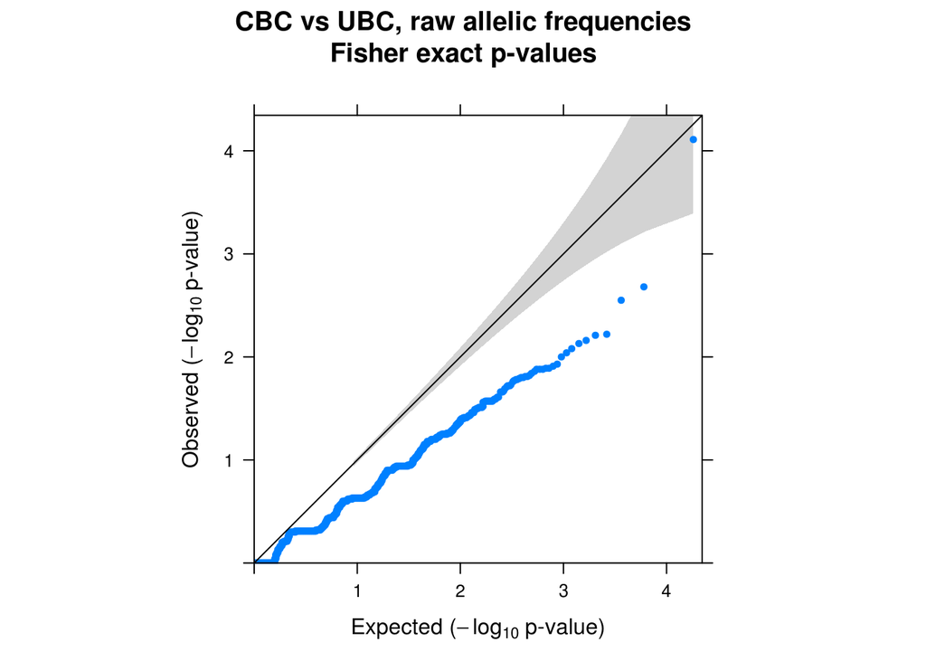

```r
# QQ-plot
qqunif.plot(genes_aggr_info.df$cbc_ubc_fisher_p,
            main="CBC vs UBC, raw allelic frequencies\nFisher exact p-values")
```

```r
# Top 10 genes
x <- genes_aggr_info.df[,c("gene","aggr_af_ubc", "aggr_af_cbc", "cbc_ubc_call", "cbc_ubc_fisher_p")]
x <- x[order(x$cbc_ubc_fisher_p),]
x[x$cbc_ubc_fisher_p<0.01,c("aggr_af_ubc", "aggr_af_cbc", "cbc_ubc_call", "cbc_ubc_fisher_p")]
```

```
##          aggr_af_ubc  aggr_af_cbc cbc_ubc_call cbc_ubc_fisher_p
## FAM171B  0.009698276 0.0005630631   protective     7.842482e-05
## POMT1    0.022810219 0.0137085137   protective     2.102384e-03
## SUMO4    0.218237705 0.2782608696         risk     2.842540e-03
## ECM1     0.001360544 0.0086330935         risk     5.991061e-03
## CACNA1H  0.000000000 0.0031418312         risk     6.203907e-03
## ENGASE   0.017777778 0.0349922240         risk     6.897277e-03
## DNASE1L3 0.050000000 0.0257270694   protective     7.414037e-03
## SLC5A4   0.006255792 0.0024485798   protective     8.338096e-03
## CLIP1    0.017886855 0.0294894366         risk     9.141985e-03
```

```r
# Clean-up
rm(header, genes_aggr_info.mx, gene, genes,
   cbc_cases, ubc_cases,
   cbc_fam_cases, cbc_nofam_cases,
   ubc_fam_cases, ubc_nofam_cases,
   x, qqunif.plot)
```

# impute_missed_data

Substitute NA to duplicated **total** AFs (after inversion)  
Equivalent to the “fixed” imputation approach in SKAT

In contrast to the inversion and weighting I use **total** AFs, not **controls’ (ubc)** AFs here

```r
# Prepare matrix for output
genotypes_inv_imp.mx <- genotypes_inv.mx

# Fraction of missed data
sum(is.na(genotypes_inv_imp.mx))/
  (nrow(genotypes_inv_imp.mx)*ncol(genotypes_inv_imp.mx)) # ~2.7%
```

```
## [1] 0.02695949
```

```r
# Impute missed data
for(var in 1:nrow(genotypes_inv_imp.mx)){

    # Get AF (corrected for the inverted variants)
    af <- variants_inv.df[var,"af_inv"]

    # Impute missed genotypes
    genotypes <- genotypes_inv_imp.mx[var,]
    2*af -> genotypes[is.na(genotypes)]
    genotypes -> genotypes_inv_imp.mx[var,]

    # Clean-up
    rm(af, genotypes)

}

# Check the result
sum(is.na(genotypes_inv_imp.mx)) # 0%
```

```
## [1] 0
```

```r
# Clean-up
rm(genotypes_inv.mx, var)
```

# weight_variants_by_af_in_controls

To do: ask DC about possible effect for one-variant genes (I expect no efect) ?

```r
# Prepare tables for output
variants_inv_wt.df <- variants_inv.df
variants_inv_wt.df <- cbind(variants_inv_wt.df, weight=1)

genotypes_inv_imp_wt.mx <- genotypes_inv_imp.mx

# Apply weighting
for(var in 1:nrow(genotypes_inv_imp_wt.mx)){

  # Calculate weight (use UBC AF, recalculated for inverted variants)
  weight <- dbeta(variants_inv_wt.df[var, "af_ubc_inv"], 1, 25)

  # Write weight to variants table
  weight -> variants_inv_wt.df[var,"weight"]

  # Apply weights to genotypes table
  weight * genotypes_inv_imp_wt.mx[var,] -> genotypes_inv_imp_wt.mx[var,]

  # Clean-up
  rm(weight)

}

# clean-up
rm(var, genotypes_inv_imp.mx, variants_inv.df)
```

# aggregate_data_per_gene

```r
# Get list of genes (get rid of NAs !)
genes <- unique(as.character(variants_inv_wt.df$SYMBOL))
length(genes)
```

```
## [1] 9117
```

```r
sum(is.na(genes))
```

```
## [1] 0
```

```r
# Prepare results matrix
genes_aggr_data.mx <- matrix(nrow=0, ncol=ncol(genotypes_inv_imp_wt.mx))
colnames(genes_aggr_data.mx) <- colnames(genotypes_inv_imp_wt.mx)

for(gene in genes){

  # Get list of variants
  vars <- variants_inv_wt.df$SYMBOL == gene

  # Get genotypes matrices
  gt.mx <- genotypes_inv_imp_wt.mx[vars, , drop=FALSE]

  # Aggregate
  aggr_gene <- apply(gt.mx,2,sum)

  # Add to results matrix
  genes_aggr_data.mx <- rbind(genes_aggr_data.mx, aggr_gene)

  # Clean-up
  rm(vars, gt.mx, aggr_gene)

}

# Add rownames
genes -> rownames(genes_aggr_data.mx)

# Check result
dim(genes_aggr_data.mx)
```

```
## [1] 9117  478
```

```r
# Clean-up
variants.df <- variants_inv_wt.df
rm(gene, genes, variants_inv_wt.df)
```

# data_summary

```r
dim(genotypes.mx)
```

```
## [1] 18551   478
```

```r
class(genotypes.mx)
```

```
## [1] "matrix"
```

```r
genotypes.mx[1:5,1:5]
```

```
##              P1_A01 P1_A02 P1_A03 P1_A04 P1_A05
## Var000000026      0     NA      0      0      0
## Var000000029      0      0      0      0      0
## Var000000031      0      0      0      0      0
## Var000000053      0      0      0      0     NA
## Var000000064      0      0      0      0     NA
```

```r
dim(genotypes_inv_imp_wt.mx)
```

```
## [1] 18551   478
```

```r
class(genotypes_inv_imp_wt.mx)
```

```
## [1] "matrix"
```

```r
genotypes_inv_imp_wt.mx[1:5,1:5]
```

```
##              P1_A01     P1_A02 P1_A03 P1_A04     P1_A05
## Var000000026      0 0.05482456      0      0 0.00000000
## Var000000029      0 0.00000000      0      0 0.00000000
## Var000000031      0 0.00000000      0      0 0.00000000
## Var000000053      0 0.00000000      0      0 0.05707763
## Var000000064      0 0.00000000      0      0 0.05518764
```

```r
dim(genes_aggr_data.mx)
```

```
## [1] 9117  478
```

```r
class(genes_aggr_data.mx)
```

```
## [1] "matrix"
```

```r
genes_aggr_data.mx[1:5,1:5]
```

```
##        P1_A01     P1_A02     P1_A03   P1_A04    P1_A05
## NOC2L       0 0.05482456 0.00000000 0.000000 0.0000000
## KLHL17      0 0.00000000 0.00000000 0.000000 0.1122653
## AGRN        0 0.65431621 0.00000000 8.602334 0.0000000
## TTLL10      0 0.00000000 0.00000000 0.000000 0.0000000
## PUSL1       0 0.05821459 0.05821459 0.000000 0.0000000
```

```r
dim(genes_aggr_info.df)
```

```
## [1] 9117   27
```

```r
str(genes_aggr_info.df)
```

```
## 'data.frame':    9117 obs. of  27 variables:
##  $ gene             : chr  "NOC2L" "KLHL17" "AGRN" "TTLL10" ...
##  $ num_var          : num  3 2 3 1 1 1 1 1 2 1 ...
##  $ inverted         : logi  FALSE FALSE FALSE FALSE FALSE FALSE ...
##  $ multiallelic     : logi  FALSE FALSE FALSE FALSE FALSE FALSE ...
##  $ aggr_ac          : num  4 2 36 2 1 1 1 41 3 1 ...
##  $ aggr_an          : num  2808 1782 2792 956 810 ...
##  $ aggr_af          : num  0.00142 0.00112 0.01289 0.00209 0.00123 ...
##  $ aggr_ac_cbc      : num  3 2 15 2 0 1 1 20 2 0 ...
##  $ aggr_an_cbc      : num  1358 870 1360 466 400 ...
##  $ aggr_af_cbc      : num  0.00221 0.0023 0.01103 0.00429 0 ...
##  $ aggr_ac_ubc      : num  1 0 21 0 1 0 0 21 1 1 ...
##  $ aggr_an_ubc      : num  1450 912 1432 490 410 ...
##  $ aggr_af_ubc      : num  0.00069 0 0.01466 0 0.00244 ...
##  $ aggr_ac_cbc_fam  : num  1 0 5 2 0 0 1 9 0 0 ...
##  $ aggr_an_cbc_fam  : num  482 306 478 166 144 162 164 164 318 150 ...
##  $ aggr_af_cbc_fam  : num  0.00207 0 0.01046 0.01205 0 ...
##  $ aggr_ac_cbc_nofam: num  2 2 10 0 0 1 0 11 2 0 ...
##  $ aggr_an_cbc_nofam: num  876 564 882 300 256 298 296 300 566 290 ...
##  $ aggr_af_cbc_nofam: num  0.00228 0.00355 0.01134 0 0 ...
##  $ aggr_ac_ubc_fam  : num  0 0 4 0 1 0 0 8 0 1 ...
##  $ aggr_an_ubc_fam  : num  418 262 414 142 120 140 142 142 278 132 ...
##  $ aggr_af_ubc_fam  : num  0 0 0.00966 0 0.00833 ...
##  $ aggr_ac_ubc_nofam: num  1 0 17 0 0 0 0 13 1 0 ...
##  $ aggr_an_ubc_nofam: num  1032 650 1018 348 290 ...
##  $ aggr_af_ubc_nofam: num  0.000969 0 0.016699 0 0 ...
##  $ cbc_ubc_call     : Factor w/ 3 levels "protective","risk",..: 2 2 1 2 1 2 2 2 2 1 ...
##  $ cbc_ubc_fisher_p : num  0.359 0.238 0.408 0.237 1 ...
```

```r
genes_aggr_info.df[1:5,1:5]
```

```
##          gene num_var inverted multiallelic aggr_ac
## NOC2L   NOC2L       3    FALSE        FALSE       4
## KLHL17 KLHL17       2    FALSE        FALSE       2
## AGRN     AGRN       3    FALSE        FALSE      36
## TTLL10 TTLL10       1    FALSE        FALSE       2
## PUSL1   PUSL1       1    FALSE        FALSE       1
```

```r
dim(kgen.df)
```

```
## [1] 18551     9
```

```r
colnames(kgen.df)
```

```
## [1] "SplitVarID"  "kgen.AC"     "kgen.AN"     "kgen.AF"     "kgen.AFR_AF"
## [6] "kgen.AMR_AF" "kgen.EAS_AF" "kgen.EUR_AF" "kgen.SAS_AF"
```

```r
kgen.df[1:5,1:5]
```

```
##                SplitVarID kgen.AC kgen.AN     kgen.AF kgen.AFR_AF
## Var000000026 Var000000026      NA      NA          NA          NA
## Var000000029 Var000000029       1    5008 0.000199681           0
## Var000000031 Var000000031       1    5008 0.000199681           0
## Var000000053 Var000000053      NA      NA          NA          NA
## Var000000064 Var000000064      NA      NA          NA          NA
```

```r
dim(exac.df)
```

```
## [1] 18551    48
```

```r
colnames(exac.df)
```

```
##  [1] "SplitVarID"              "exac_non_TCGA.AF"
##  [3] "exac_non_TCGA.AC"        "exac_non_TCGA.AN"
##  [5] "exac_non_TCGA.AC_FEMALE" "exac_non_TCGA.AN_FEMALE"
##  [7] "exac_non_TCGA.AC_MALE"   "exac_non_TCGA.AN_MALE"
##  [9] "exac_non_TCGA.AC_Adj"    "exac_non_TCGA.AN_Adj"
## [11] "exac_non_TCGA.AC_Hom"    "exac_non_TCGA.AC_Het"
## [13] "exac_non_TCGA.AC_Hemi"   "exac_non_TCGA.AC_AFR"
## [15] "exac_non_TCGA.AN_AFR"    "exac_non_TCGA.Hom_AFR"
## [17] "exac_non_TCGA.Het_AFR"   "exac_non_TCGA.Hemi_AFR"
## [19] "exac_non_TCGA.AC_AMR"    "exac_non_TCGA.AN_AMR"
## [21] "exac_non_TCGA.Hom_AMR"   "exac_non_TCGA.Het_AMR"
## [23] "exac_non_TCGA.Hemi_AMR"  "exac_non_TCGA.AC_EAS"
## [25] "exac_non_TCGA.AN_EAS"    "exac_non_TCGA.Hom_EAS"
## [27] "exac_non_TCGA.Het_EAS"   "exac_non_TCGA.Hemi_EAS"
## [29] "exac_non_TCGA.AC_FIN"    "exac_non_TCGA.AN_FIN"
## [31] "exac_non_TCGA.Hom_FIN"   "exac_non_TCGA.Het_FIN"
## [33] "exac_non_TCGA.Hemi_FIN"  "exac_non_TCGA.AC_NFE"
## [35] "exac_non_TCGA.AN_NFE"    "exac_non_TCGA.Hom_NFE"
## [37] "exac_non_TCGA.Het_NFE"   "exac_non_TCGA.Hemi_NFE"
## [39] "exac_non_TCGA.AC_SAS"    "exac_non_TCGA.AN_SAS"
## [41] "exac_non_TCGA.Hom_SAS"   "exac_non_TCGA.Het_SAS"
## [43] "exac_non_TCGA.Hemi_SAS"  "exac_non_TCGA.AC_OTH"
## [45] "exac_non_TCGA.AN_OTH"    "exac_non_TCGA.Hom_OTH"
## [47] "exac_non_TCGA.Het_OTH"   "exac_non_TCGA.Hemi_OTH"
```

```r
exac.df[1:5,1:5]
```

```
##                SplitVarID exac_non_TCGA.AF exac_non_TCGA.AC
## Var000000026 Var000000026               NA               NA
## Var000000029 Var000000029        1.506e-04               16
## Var000000031 Var000000031        2.354e-04               25
## Var000000053 Var000000053        1.883e-05                2
## Var000000064 Var000000064        9.416e-06                1
##              exac_non_TCGA.AN exac_non_TCGA.AC_FEMALE
## Var000000026               NA                      NA
## Var000000029           106210                       8
## Var000000031           106210                       4
## Var000000053           106210                       0
## Var000000064           106206                       0
```

```r
dim(variants.df)
```

```
## [1] 18551    67
```

```r
str(variants.df)
```

```
## 'data.frame':    18551 obs. of  67 variables:
##  $ SplitVarID        : Factor w/ 343824 levels "Var000000001",..: 26 29 31 53 64 167 227 237 300 400 ...
##  $ SYMBOL            : Factor w/ 19862 levels "A1BG","A1CF",..: 11149 11149 11149 8665 8665 540 540 540 18233 13545 ...
##  $ TYPE              : Factor w/ 2 levels "INDEL","SNP": 2 2 2 2 2 2 2 2 2 2 ...
##  $ CHROM             : Factor w/ 25 levels "1","10","11",..: 1 1 1 1 1 1 1 1 1 1 ...
##  $ POS               : int  881871 883883 883946 897287 897792 979748 987173 989899 1132513 1246373 ...
##  $ REF               : Factor w/ 2142 levels "A","AAAAAAAAAAAAAAAAAAAAAAAG",..: 1044 1575 539 539 539 1 1575 539 539 1044 ...
##  $ ALT               : Factor w/ 1297 levels "A","AAAAAAAAAAAAACT",..: 1 323 989 989 989 989 664 989 989 1 ...
##  $ ac_raw            : int  1 2 1 1 1 53 1 1 2 1 ...
##  $ af_raw            : num  0.000711 0.001555 0.000774 0.000711 0.000722 ...
##  $ an_raw            : int  1406 1286 1292 1406 1386 1416 1420 1414 1320 1400 ...
##  $ Consequence       : Factor w/ 78 levels "3_prime_UTR_variant",..: 66 28 28 28 66 28 28 28 28 28 ...
##  $ SIFT_call         : Factor w/ 4 levels "deleterious",..: NA 1 1 1 NA 1 1 1 1 1 ...
##  $ SIFT_score        : num  NA 0 0.01 0.04 NA 0.01 0 0.02 0.02 0.05 ...
##  $ PolyPhen_call     : Factor w/ 4 levels "benign","possibly_damaging",..: NA 3 3 3 NA 3 3 3 3 3 ...
```

[output cut: 53 more lines]

```r
variants.df[1:5,1:5]
```

```
##                SplitVarID SYMBOL TYPE CHROM    POS
## Var000000026 Var000000026  NOC2L  SNP     1 881871
## Var000000029 Var000000029  NOC2L  SNP     1 883883
## Var000000031 Var000000031  NOC2L  SNP     1 883946
## Var000000053 Var000000053 KLHL17  SNP     1 897287
## Var000000064 Var000000064 KLHL17  SNP     1 897792
```

```r
dim(phenotypes.df)
```

```
## [1] 478  36
```

```r
str(phenotypes.df)
```

```
## 'data.frame':    478 obs. of  36 variables:
##  $ wes_id        : chr  "P1_A01" "P1_A02" "P1_A03" "P1_A04" ...
##  $ gwas_id       : chr  "id203568" "id357807" "id325472" "id304354" ...
##  $ merged_id     : chr  "P1_A01_id203568" "P1_A02_id357807" "P1_A03_id325472" "P1_A04_id304354" ...
##  $ filter        : chr  "pass" "pass" "pass" "pass" ...
##  $ cc            : int  1 1 1 1 1 1 0 1 1 0 ...
##  $ setno         : int  203568 357807 325472 304354 222648 244843 276284 297810 250898 226974 ...
##  $ registry      : Factor w/ 5 levels "de","IA","IR",..: 3 4 2 2 5 4 2 4 4 2 ...
##  $ family_history: int  1 0 1 1 1 1 1 1 1 0 ...
##  $ age_dx        : int  49 35 32 33 44 28 28 38 35 36 ...
##  $ age_ref       : num  58 36 41 34 49 28 32 44 35 38 ...
##  $ rstime        : num  10.17 1.83 9.75 1.59 5.66 ...
##  $ eig1_gwas     : num  -0.00389 -0.00379 -0.01011 -0.01288 -0.01086 ...
##  $ eig2_gwas     : num  0.00266 0.00246 -0.0001 0.00595 0.01157 ...
##  $ eig3_gwas     : num  0.06803 0.05055 -0.00603 0.00747 0.00144 ...
```

[output cut: 22 more lines]

```r
phenotypes.df[1:5,1:5]
```

```
##        wes_id  gwas_id       merged_id filter cc
## P1_A01 P1_A01 id203568 P1_A01_id203568   pass  1
## P1_A02 P1_A02 id357807 P1_A02_id357807   pass  1
## P1_A03 P1_A03 id325472 P1_A03_id325472   pass  1
## P1_A04 P1_A04 id304354 P1_A04_id304354   pass  1
## P1_A05 P1_A05 id222648 P1_A05_id222648   pass  1
```

```r
# Check consistency of rownames and colnames
sum(colnames(genotypes.mx) != rownames(phenotypes.df))
```

```
## [1] 0
```

```r
sum(colnames(genes_aggr_data.mx) != rownames(phenotypes.df))
```

```
## [1] 0
```

```r
sum(rownames(genes_aggr_info.df) != rownames(genes_aggr_data.mx))
```

```
## [1] 0
```

```r
sum(rownames(genotypes.mx) != rownames(genotypes_inv_imp_wt.mx))
```

```
## [1] 0
```

```r
sum(rownames(genotypes.mx) != rownames(kgen.df))
```

```
## [1] 0
```

```r
sum(rownames(genotypes.mx) != rownames(exac.df))
```

```
## [1] 0
```

```r
sum(rownames(genotypes.mx) != rownames(variants.df))
```

```
## [1] 0
```

# save_data

```r
save.image(paste(base_folder, "results", "r10a_invert_impute_weight_aggregate_wecare_only.RData", sep="/"))
```

# final_section

```r
ls()
```

```
## [1] "base_folder"             "exac.df"
## [3] "genes_aggr_data.mx"      "genes_aggr_info.df"
## [5] "genotypes_inv_imp_wt.mx" "genotypes.mx"
## [7] "kgen.df"                 "phenotypes.df"
## [9] "variants.df"
```

```r
Sys.time()
```

```
## [1] "2017-05-05 15:10:11 BST"
```